# Introduction to R programming for data science Day 1 exercises

Dr. Francesca Finotello

Medical University of Innsbruck, Austria

# Rstudio console

## Ex. 1.1

Use the Rstudio console to compute:

- The square root of 144

```r
sqrt(144)
```

```
## [1] 12
```

```r
log2(64)
```

```
## [1] 6
```

- The following formula

$$\frac{2}{3}(\sqrt{9}-log_{10}{1000})^2+\frac{5}{6}$$

```r
2/3 * ( sqrt(9) - log10(1000) )^2 + 5/6
```

```
## [1] 0.8333333
```

Have a look at the **History** panel: what do you see?

**Tip**: Once your cursor is in the Rstudio console, if you press the upwards arrow on your keyboard, you can select one of the commands you have already typed.

# Variables and operations

## Ex. 1.2

Assign the value 2 to a variable called *x*.

```r
x <- 2
```

Assign the value 10 to a variable called *y*.

```r
y <- 10
```

Check whether *x* and *y* are equal.

```r
x == y
```

```
## [1] FALSE
```

Check whether *y* and *x* are different.

```r
x != y
```

```
## [1] TRUE
```

Check whether *y* is greater or equal to *x*.

```r
y >= x
```

```
## [1] TRUE
```

Divide *y* by *x*.

```r
y / x
```

```
## [1] 5
```

Save the remainder of the division above (i.e., the *modulus*) in a variable called *z* and print it to screen.

```r
z <- y %% x
z
```

```
## [1] 0
```

Is *y* an even number? If so, it should be divisible by 2 without remainder.

Have a look at the **Environment** panel: what do you see?

## Ex. 1.3

Try to assign the value of 5 to a variable called *4th_var*?

```r
4th_var <- 5 # Possible solution among many
```

```
## Error: <text>:2:2: unexpected symbol
## 1:
## 2: 4th_var
##     ^
```

Why is it not possible? What can you change to make the assignment work?

```r
var4 <- 5
```

## Ex. 1.4

Initialize the following variables as in the code below:

```r
Name <- "Maria"
Age <- 30
PhD <- TRUE
```

What are the classes of the three variables?

```r
class(Name)
```

```
## [1] "character"
```

```r
class(Age)
```

```
## [1] "numeric"
```

```r
class(PhD)
```

```
## [1] "logical"
```

Check whether the *PhD* variable is *NA*.

```r
is.na(PhD)
```

```
## [1] FALSE
```

## Ex. 1.5

Initialize the following variables as in the code below:

```r
x <- -5
y <- 0
z <- x / y
```

What is the value of *z*?

## Ex. 1.6

Save the length of the base and height of the rectangle depicted below into two numeric variables called *b* and *h*:

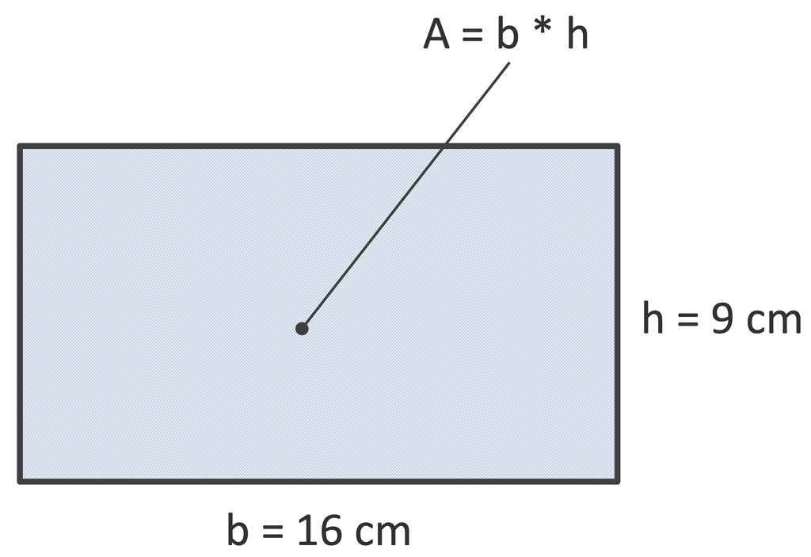

```r
b <- 16
h <- 9
```

Compute the area of the rectangle, save it into a numeric variable called *A*, and check whether it is bigger than 100 cm<sup>2</sup>.

```r
A <- b*h
A > 100
```

```
## [1] TRUE
```

# Data structures: vectors and factors

## Ex. 1.7

Save the first 10 integers into a vector called *num* and check its class. **Tip**: use the *seq* function to initialize the vector.

```r
num <- seq(1, 10)
class(num)
```

```
## [1] "integer"
```

Save the first 5 letters of the alphabet in a vector called *alpha* and check its class.

```r
alpha <- c ("a", "b", "c", "d", "e")
class(alpha)
```

```
## [1] "character"
```

**Advanced**: the *letters* object built-in in R contains all the letters of the alphabet.

```r
alpha <- letters[1:5]
class(alpha)
```

```
## [1] "character"
```

Concatenate *num* and *alpha*, save the resulting vector in a variable calles *mix*, and check its class. Is it a numeric or character vector?

```r
mix <- c( num, alpha )
class(mix)
```

```
## [1] "character"
```

## Ex. 1.8

Build a factor variable called *expDesign* storing the information about which mice is wild type (“WT”) or mutant (“MU”) in the figure below.

**Tip**: use the **rep**, **c**, and **factor** functions.

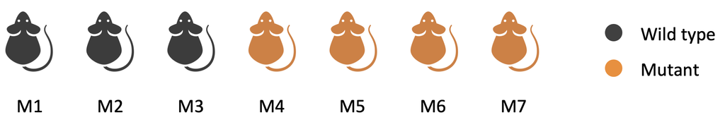

```r
expDesign <- factor( c( rep("WT", 3), rep("MT", 4) ) )
```

Check the class, length, and levels of your variable **expDesign**.

```r
class(expDesign)
```

```
## [1] "factor"
```

```r
levels(expDesign)
```

```
## [1] "MT" "WT"
```

```r
length(expDesign)
```

```
## [1] 7
```

Assign the mice identifiers (M1, M2, …) to the same variable using the **names** function.

```r
names(expDesign) <- c("M1", "M2", "M3", "M4", "M5", "M6", "M7")
expDesign
```

```
## M1 M2 M3 M4 M5 M6 M7
## WT WT WT MT MT MT MT
## Levels: MT WT
```

**Advanced**: the **paste** function can be used to concatenate strings.

```r
names(expDesign) <- paste ("M", seq(1, 7), sep="")
expDesign
```

```
## M1 M2 M3 M4 M5 M6 M7
## WT WT WT MT MT MT MT
## Levels: MT WT
```

# Manipulating vectors

## Ex. 1.9

Initialize the following vector in R:

```r
age <- c(11, 12, 34, 89, 45, 90, 12)
```

Select only the elements of the *age* vector that are greater or equal to 18 by using a logical index (i.e., `age >= 18`) and a numerical index (i.e., `which(age >= 18)`).

```r
age[age>=18]
```

```
## [1] 34 89 45 90
```

```r
age[which(age>=18)]
```

```
## [1] 34 89 45 90
```

What is the difference of the `age >= 18` and `which(age >= 18)` indexes in terms of values, class, and length?

```r
age >= 18
```

```
## [1] FALSE FALSE  TRUE  TRUE  TRUE  TRUE FALSE
```

```r
which(age >= 18)
```

```
## [1] 3 4 5 6
```

```r
class(age >= 18)
```

```
## [1] "logical"
```

```r
class(which(age >= 18))
```

```
## [1] "integer"
```

```r
length(age >= 18)
```

```
## [1] 7
```

```r
length(which(age >= 18))
```

```
## [1] 4
```

## Ex. 1.10

Initialize the following vector in R:

```r
x <- c(0, -1, 3, 10, -14, 7.5, 9)
```

- Positive indexes (to indicate which elements should be selected)

```r
y <- x[ c(3, 4, 6, 7) ]
y
```

```
## [1]  3.0 10.0  7.5  9.0
```

- Negative indexes (to indicate which elements should be discarded)

```r
y <- x[ -c(1, 2, 5) ]
y
```

```
## [1]  3.0 10.0  7.5  9.0
```

- A logical vector

```r
y <- x[ c(FALSE, FALSE, TRUE,TRUE, FALSE, TRUE, TRUE) ]
y
```

```
## [1]  3.0 10.0  7.5  9.0
```

- A “rule” using > or ≤

```r
y <- x[ x>0 ]
y
```

```
## [1]  3.0 10.0  7.5  9.0
```

## Ex. 1.11

Initialize in R the following named vector of gene expression levels:

```r
normExpr <- c(10.2, 11.4, 4.0)
names(normExpr) <- c("CD8A", "CD8B", "PDCD1")
```

Access the expression of CD8A and CD8B genes by using:

- Positive indexes

```r
normExpr[ c(1, 2)]
```

```
## CD8A CD8B
## 10.2 11.4
```

- Vector names

```r
normExpr[ c("CD8A", "CD8B") ]
```

```
## CD8A CD8B
## 10.2 11.4
```

## Ex. 1.12

Initialize in R the following vector of estimated cell fractions:

```r
cellFractions <- c(-0.1, 0.4, -0.4, 0.5, 0.2)
```

Set to 0 all negative cell fractions.

```r
cellFractions[ cellFractions<0 ] <- 0
cellFractions
```

```
## [1] 0.0 0.4 0.0 0.5 0.2
```